# アドレス帳アプリの作成と第9回課題

> オブジェクト指向プログラミングおよび演習2

# アドレス帳アプリの作成

今回作成するプログラムは、氏名（名と姓）、メールアドレスを記録する簡単なアドレス帳アプリを作成します。

今回、データの画面表示の部分は講義内で一緒に行います。 課題としては、データの登録処理がきちんと行えるようにしましょう。

## 1. サーバープログラムの用意

以下の構成でプロジェクトディレクトリを作成します。K00000は、各自の学籍番号に置き換えてください。

```
[K00000_09]
  ├[static]
      └addressbook.js
  ├[templates]
      └addressbook.html
  ├address.json ⇠ アドレス帳のデータ保存場所
  └main.py
```

```python
from flask import Flask, request, render_template, jsonify
import json  # Python標準のJSONライブラリを読み込んで、データの保存等に使用する

app = Flask(__name__)
app.config["JSON_AS_ASCII"] = False  # 日本語などのASCII以外の文字列を返したい場合は、こちらを設定しておく


# http://127.0.0.1:5000/address
@app.route('/address', methods=["GET"])
def address_get():

    # 検索パラメータの取得
    p_first_name = request.args.get('fn', None)
    p_last_name = request.args.get('ln', None)
    p_email = request.args.get('em', None)

    with open('address.json') as f:
        json_data = json.load(f)

    # パラメータにより返すデータをフィルタリングする
    if p_first_name is not None:
        json_data = list(filter(lambda item: p_first_name.lower() in item["first_name"].lower(), json_data))
    if p_last_name is not None:
        json_data = list(filter(lambda item: p_last_name.lower() in item["last_name"].lower(), json_data))
    if p_email is not None:
        json_data = list(filter(lambda item: p_email.lower() in item["email"].lower(), json_data))

    return jsonify(json_data)


# http://127.0.0.1:5000/
@app.route('/')
def index():
    return render_template("addressbook.html")


if __name__ == "__main__":
    # debugモードが不要の場合は、debug=Trueを消してください
    app.run(debug=True)
```

### address.json

```json
[
    {
        "email": "taro.suzuki@ait.jp",
        "first_name": "Taro",
        "last_name": "Suzuki"
    },
    {
        "email": "jiro.tanaka@ait.jp",
        "first_name": "Jiro",
        "last_name": "Tanaka"
    },
    {
        "email": "saburo.suzuki@ait.jp",
        "first_name": "Saburo",
        "last_name": "Suzuki"
    }
]
```

## 2. クライアントサイドプログラムの用意

また、これらのファイルは改変自由です。必要に応じて変更してください。

### HTML (templates/addressbook.html)

```html
<!DOCTYPE html>
<html lang="ja">
<head>
    <meta charset="utf-8">
    <meta name="viewport" content="width=device-width, initial-scale=1">
    <title>アドレス帳</title>

    <!-- new.css -->
    <link rel="stylesheet" href="https://fonts.xz.style/serve/inter.css">
    <link rel="stylesheet" href="https://cdn.jsdelivr.net/npm/@exampledev/new.css@1.1.2/new.min.css">

    <!-- メッセージ表示用のCSSを定義 -->
    <style>
        #message-container,
        #error-container {
            padding: 1rem;
            border: 1px solid #e9ecef;
            border-left-width: 0.25rem;
            border-left-color: #5bc0de;
            border-radius: 0.25rem;
        }
        #error-container {
            color: #dc3545;
        }
    </style>

    <script defer src="{{ url_for('static', filename='addressbook.js') }}"></script>
</head>
<body>
    <header>
        <h1>アドレス帳</h1>
    </header>
    <main>
        <section>
            <form id="search">
                <div>
                    <input type="text" id="search-firstname" placeholder="First name" name="fn">
                    <input type="text" id="search-lastname" placeholder="Last name" name="ln">
                    <input type="text" id="search-email" placeholder="Email address" name="em">
                    <button id="search-submit">Search</button>
                </div>
            </form>
        </section>
        <table id="address-list">
            <thead>
                <tr>
                    <th scope="col">First Name</th>
                    <th scope="col">Last Name</th>
                    <th scope="col">Email</th>
                </tr>
            </thead>
            <tbody>

            </tbody>
        </table>

        <section>
            <h3>データの追加</h3>
            <form id="add">
                <div>
                    <input required type="text" id="add-firstname" placeholder="First name" name="fn">
                    <input required type="text" id="add-lastname" placeholder="Last name" name="ln">
                    <input required type="text" id="add-email" placeholder="Email address" name="em">
                    <button id="add-submit">Add</button>
                </div>
            </form>

            <!-- メッセージの表示領域 （サンプルでは使いません。課題のタイミングで使用してもOKです。） -->
            <div id="message-container" role="alert" style="display: none;"></div>
            <div id="error-container" role="alert" style="display: none;"></div>
        </section>
    </main>
</body>
</html>
```

### JavaScript (static/addressbook.js)

```javascript
// データの初期表示
fetch("/address").then(response => {
    console.log(response);
    response.json().then((data) => {
        console.log(data);  // 取得されたレスポンスデータをデバッグ表示
        // データを表示させる
        const tableBody = document.querySelector("#address-list > tbody");
        data.forEach(elm => {
            // 1行づつ処理を行う
            let tr = document.createElement('tr');
            // first name
            let td = document.createElement('td');
            td.innerText = elm.first_name;
            tr.appendChild(td);
            // last name
            td = document.createElement('td');
            td.innerText = elm.last_name;
            tr.appendChild(td);
            // email
            td = document.createElement('td');
            td.innerText = elm.email;
            tr.appendChild(td);

            // 1行分をtableタグ内のtbodyへ追加する
            tableBody.appendChild(tr);
        });
    });
});
```

### いったん動作確認をしましょう

正しく動作していれば、以下の画面のような表示になるはずです。

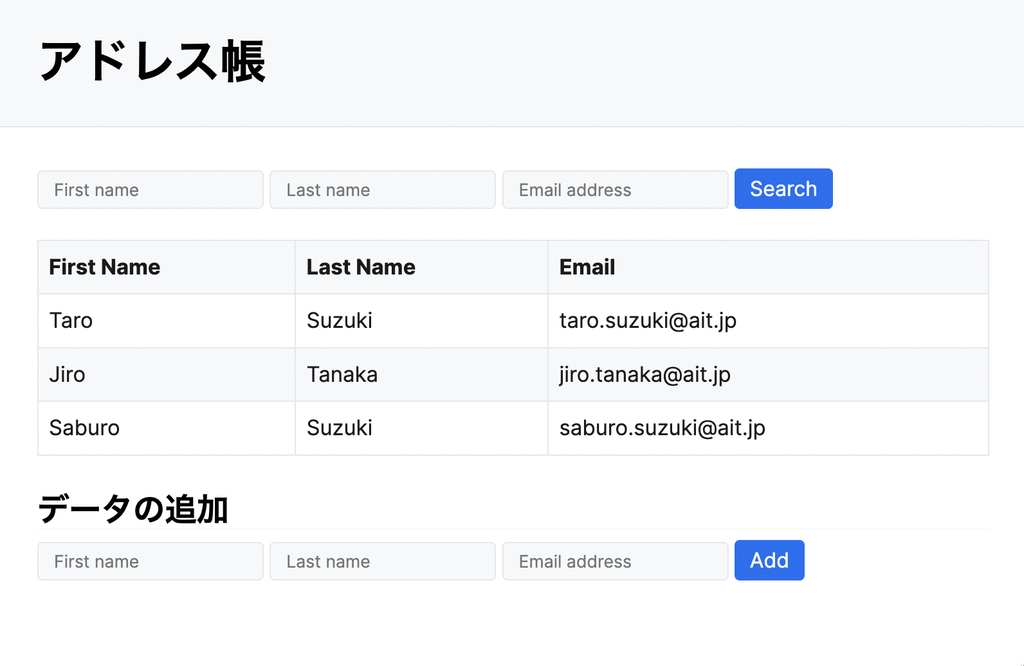

## 【課題1】 3. データの検索が行えるようにしよう

データが表示されているtableの上部に配置されているフォームは、表示データの検索フォームです。

その他の機能を追加したい場合は、上記仕様を守った上で追加してもらって構いません。

### データ検索のサーバープログラム呼び出し

クエリパラメータを指定しない場合、初期表示で行っているデータの取得と同じになります。

### データ検索のヒント

JavaScript側のボタン押下後の処理にて、クエリパラメータの生成を正しく行えるようにしましょう。 Last Nameに「Suzuki」が含まれるデータを検索したい場合のURIは、`/address?ln=Suzuki`となります。

JavaScirptのAPIとして、`URLSearchParams`が実装されています。 こちらのAPIを使用すると、クエリパラメータの構築が簡単です。

- [URLSearchParams - Web API | MDN](https://developer.mozilla.org/ja/docs/Web/API/URLSearchParams)

## 【課題2】 4. データの登録が行えるようにしよう

データ表示領域の下部にあるフォームは、データ登録用のフォームです。

`Add`ボタン押下後の機能を以下の仕様で実装してください。

1. すべての入力項目はすべて必須入力とする
   - Addボタン押下時、未入力項目があればフォーム内のどこかに未入力項目があるメッセージを表示する
2. データ登録のWeb APIは`/address`を`POST`メソッドで呼び出す
   - 送信内容は以下の通り（特例としてJSONデータをPOSTしても良いですその場合はサーバー側の処理も適切に行ってください。）
     - `fn`: First Nameの文字列。省略不可。
     - `ln`: Last Nameの文字列。省略不可。
     - `em`: Emailの文字列。省略不可。
3. 登録完了時、登録完了した旨をフォーム内のどこかにメッセージ表示する

その他の機能を追加したい場合は、上記仕様を守った上で追加してもらって構いません。

### データ登録のヒント

以下のサイトが参考になります。

- [Fetch を使う - Web API | MDN](https://developer.mozilla.org/ja/docs/Web/API/Fetch_API/Using_Fetch#Supplying_request_options)
- [FormData オブジェクトの利用 - 開発者ガイド | MDN](https://developer.mozilla.org/ja/docs/Web/Guide/Using_FormData_Objects)

# 提出に関して

1. プロジェクトディレクトリ（K00000_09）を圧縮して提出
   - 動作確認のために変更された`addresss.json`はデバッグ等で変更されたまま提出をしてください。